# Practicals 09: Visulization workshop

BE_22 Bioinformatics SS 21

January Weiner

2021-06-24

# Simple graphics with ggplot2.

The package ggplot2 is a state of the art visualization framework for R (and Python). However, its logic is not as simple as “plot x versus y”. Basically, we first define “coding”, that is “aesthetics”: this is position on the screen, fill color or symbol shape (etc.). Next, we tell the package what to do with it: make a barplot, boxplot, scatter plot etc.

Also, those are not “plotting commands”. Rather, a plot is an object that can be assigned to a variable. When the variable gets printed, the plot will be displayed.

```r
library(ggplot2)
data(iris)
p <- ggplot(iris, aes(x=Sepal.Width, y=Sepal.Length))
```

This doesn’t do anything yet. We merely set up the stage. Now we can use the `+` symbol to add components to the plot.

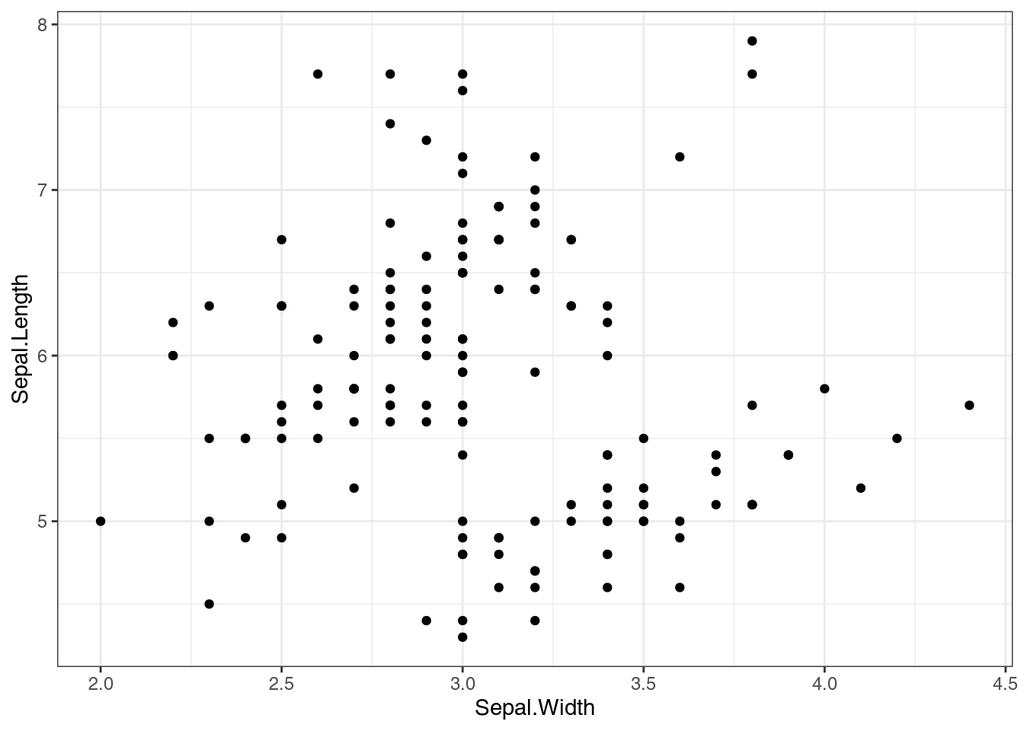

```r
p + geom_point()
```

This is a beginning, but where is the color? Well, we did not define the color esthetics. Also, there is no real need to use the p variable, that was just for demonstration purposes.

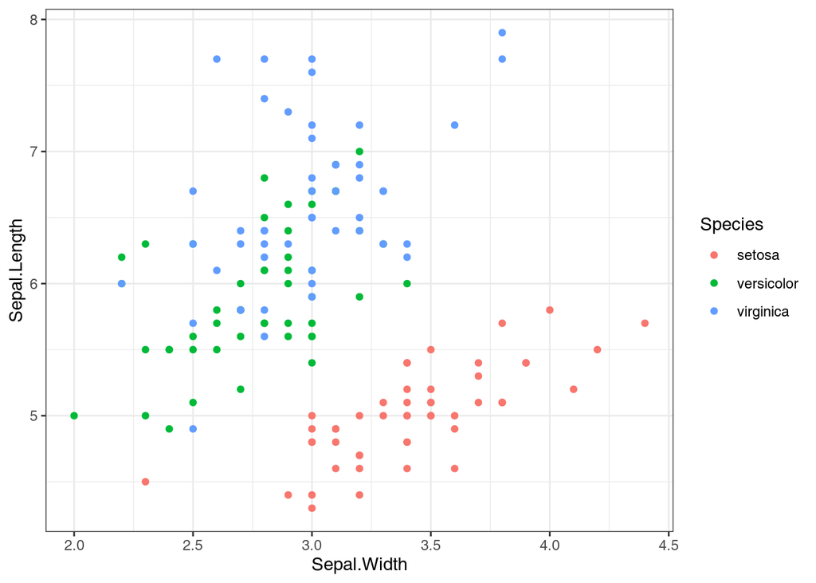

```r
ggplot(iris, aes(x=Sepal.Width, y=Sepal.Length, color=Species)) + geom_point()
```

**Exercise.** Define a data frame as follows:

```r
df <- data.frame(varX=rnorm(20),
                 varY=rnorm(20))
```

Plot varX vs. varY. Add some axis labels (e.g. “Variable X”) using the components `xlab` and `ylab`; that is, add to the plot `xlab("Variable X")`.

## Setting themes

Before we continue, let us get rid of this ugly grey panel:

```r
theme_set(theme_bw())
```

The `theme_bw()` function returns an object which is a ggplot theme, and `theme_set()` sets it globally for all the following function calls.

# Different types of plots with ggplot

There are many, many types of plots which can be drawn with ggplot.

## Barplots

How many cars are there with different number of cylinders in the `mtcars` data set?

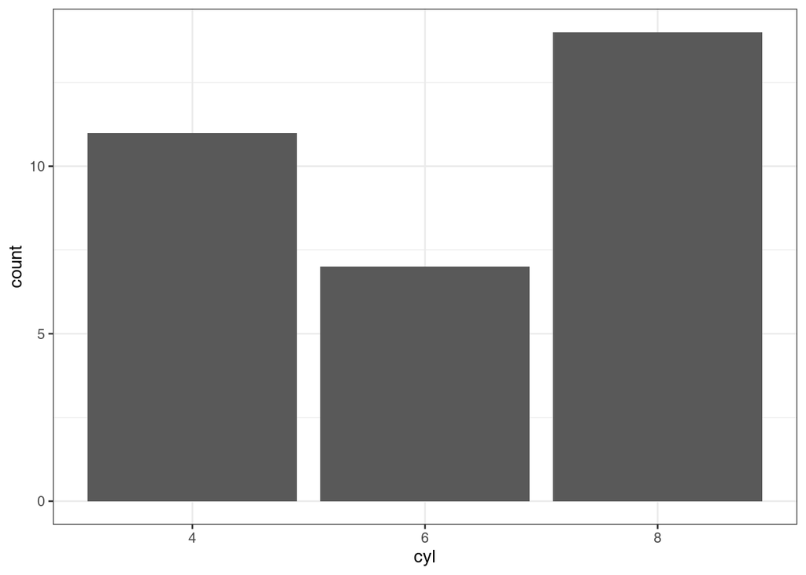

```r
mtcars$cyl <- factor(mtcars$cyl)
ggplot(mtcars, aes(x=cyl)) + geom_bar()
```

The `geom_bar` function summarizes the number of cars of each type for us. And how about when we already counted how many cars of a given type are there?

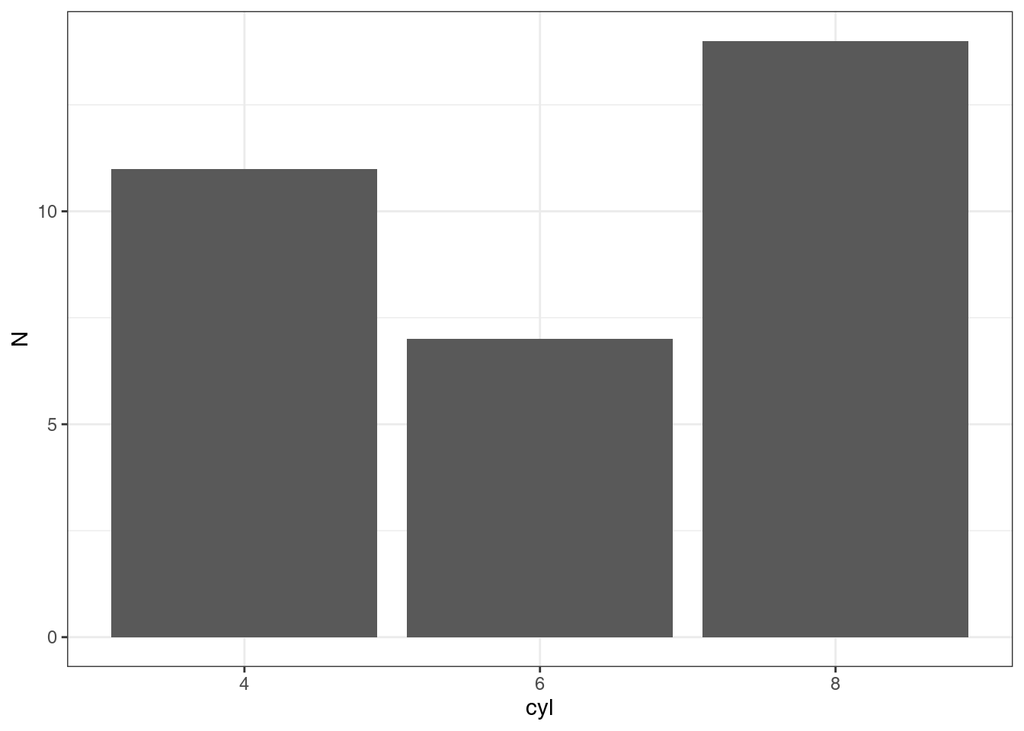

```r
df <- data.frame(cyl=factor(c(4, 6, 8)), N=c(11, 7, 14))
ggplot(df, aes(x=cyl, y=N)) + geom_bar(stat="identity")
```

The plot is identical, but the underlying data is different.

**Exercise.** What happens if you map the “fill” esthetics to the number of cylinders (`aes(..., fill=cyl)`)? What happens when you map it to something else, e.g. `gear`? And what if you convert `gear` to a factor? And what if you add the parameter `position="dodge"` to `geom_bar`?

## Boxplots

What is the average sepal width in the three species of iris?

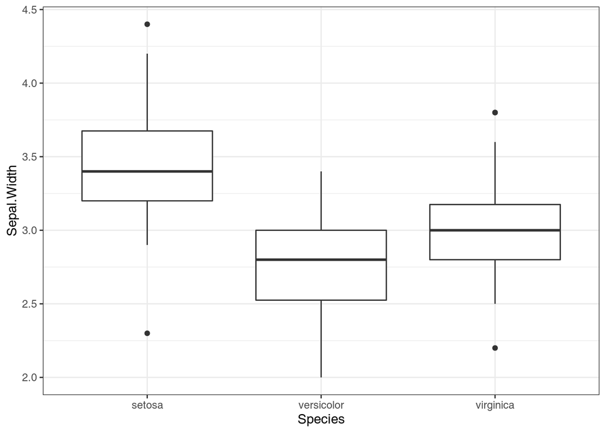

```r
ggplot(iris, aes(x=Species, y=Sepal.Width)) + geom_boxplot()
```

We can also make a violin plot:

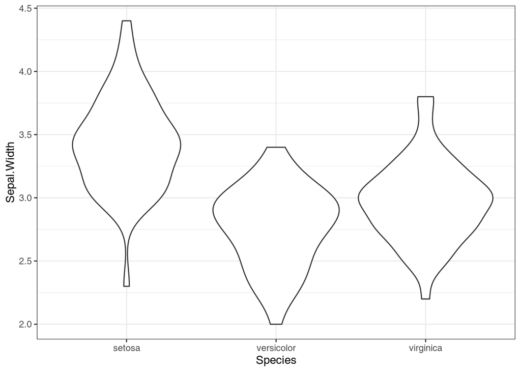

```r
ggplot(iris, aes(x=Species, y=Sepal.Width)) + geom_violin()
```

We can add the individual points, too:

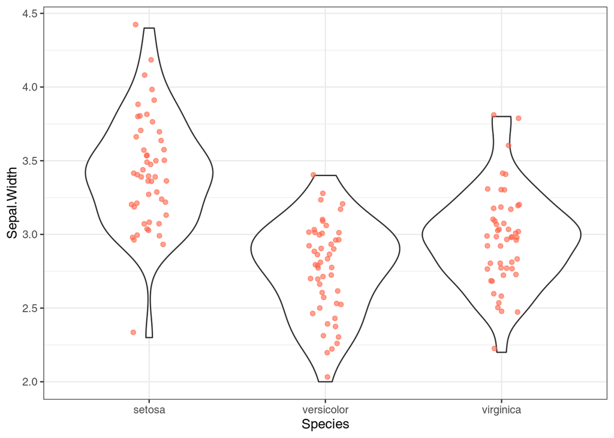

```r
ggplot(iris, aes(x=Species, y=Sepal.Width)) + geom_violin() +
  geom_jitter(alpha=.6, color="tomato", width=.1)
```

**Exercise.** Play with the settings of `geom_jitter` to figure out what they do. What is alpha? What is width?

## Line plots

Line plots are especially suitable for time series data. We now will load the World Incom Inequality Database data and select a recent time series for two countries: Germany and UK.

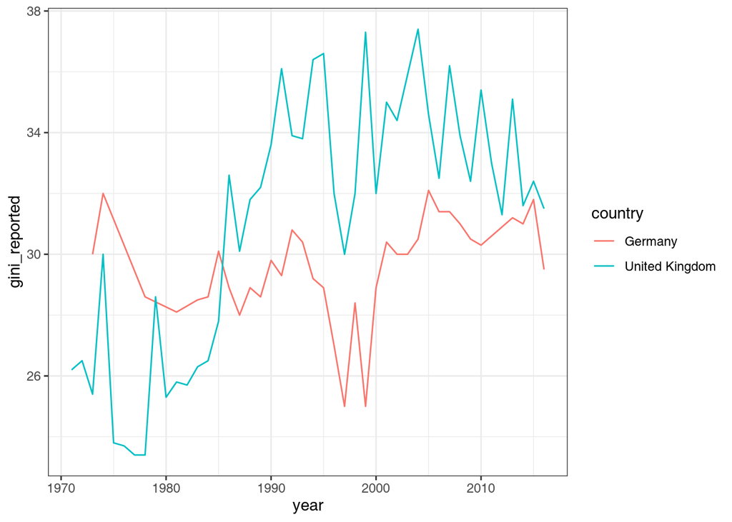

```r
library(readxl)
library(tidyverse)
wiid <- read_xlsx("../../Datasets/WIID_19Dec2018.xlsx")
wiid_sel <- wiid %>% filter(country %in% c("Germany", "United Kingdom")) %>%
  filter(!is.na(q1) & !is.na(gini_reported)) %>%
  group_by(country) %>% filter(!duplicated(year)) %>%
  filter(year > 1970)

ggplot(wiid_sel, aes(x=year, y=gini_reported, color=country)) + geom_line()
```

We can also add the points:

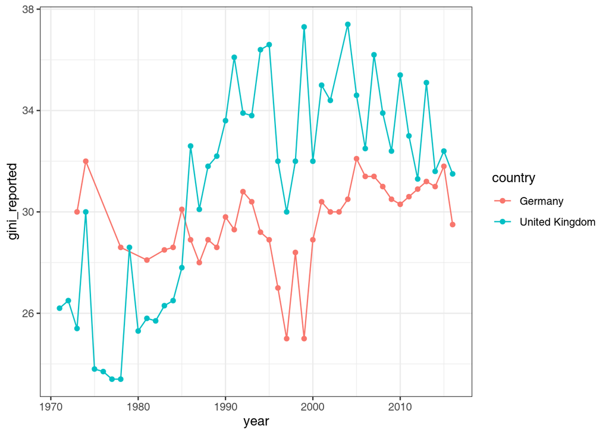

```r
ggplot(wiid_sel, aes(x=year, y=gini_reported, color=country)) + geom_line() +
  geom_point()
```

Or use facets to split the plots into sub panels (note the tilde!):

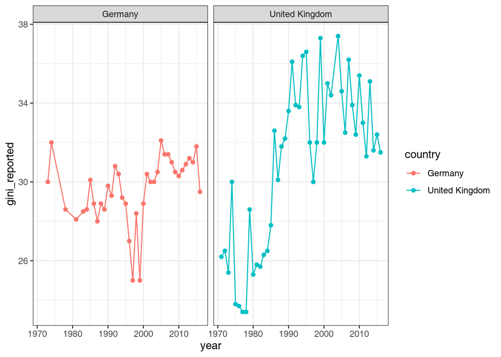

```r
ggplot(wiid_sel, aes(x=year, y=gini_reported, color=country)) + geom_line() +
  geom_point() + facet_wrap(~ country)
```

**Exercise.** From the point of view of efficient graphic design, what is wrong on the above plot? How do you correct it? Use google to learn how to get rid of the legend (the point of this exercise is not to teach you one particular tidbit of information, but rather finding that information on your own).

**Exercise.** Load the data as above, but select two other countries. Repeat the plot commands above. Now, try the same with the variable called `q1` which is the first quintile.